# Лабораторная работа №3

Моделирование графов атак

Бабенко Артём Сергеевич

1032259400@rudn.ru

Российский университет дружбы народов

2026-08-29

## Докладчик

- Бабенко Артём Сергеевич
- студент группы НФИмд-01-25
- Российский университет дружбы народов
- 1032259400@rudn.ru
- https://github.com/artyombabenko

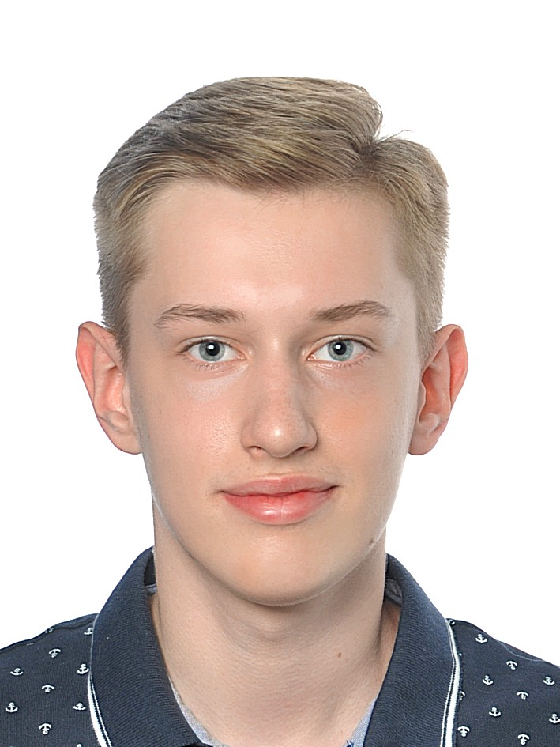

## Цель работы

- Освоить методы построения и анализа графов атак для оценки уязвимостей сетевой инфраструктуры.
- На примере моделирования атак на корпоративную сеть изучить:
  - представление сетевой топологии и уязвимостей в виде ориентированного графа;
  - алгоритмы поиска всех возможных путей атаки от начальных точек до целевых активов;
  - расчёт метрик центральности для определения критических узлов;
  - визуализацию графа с цветовой индикацией уровня риска;
  - оценку вероятности успешной атаки с учётом сложности эксплуатации уязвимостей.

## Задание

- Построить граф атак для заданной топологии сети.
- Реализовать алгоритм поиска всех путей от заданного источника к цели.
- Рассчитать метрики центральности для всех узлов и выявить наиболее критичные.
- Визуализировать граф, раскрашивая узлы в зависимости от степени риска.
- Присвоить каждому ребру вес (вероятность успешной атаки) и вычислить наиболее вероятный путь атаки.

# Выполнение лабораторной работы

## Ядро моделирования графа атак

Содержит все функции для построения ориентированного графа атак, поиска путей, расчёта метрик центральности, присвоения весов и нахождения наиболее вероятного пути. Это основной модуль, используемый всеми скриптами.

## Ядро моделирования графа атак

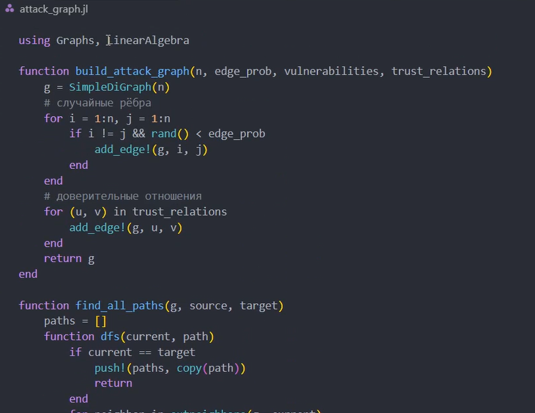

Рисунок 1: Файл attack_graph.jl

## Однократный запуск эксперимента

Файл scripts/ag_run_experiment.jl выполняет построение графа атак для заданных параметров, находит все пути, вычисляет метрики центральности, определяет наиболее вероятный путь и сохраняет результаты в JLD2-файл. Предназначен для генерации данных, которые будут анализироваться в других скриптах.

## Однократный запуск эксперимента

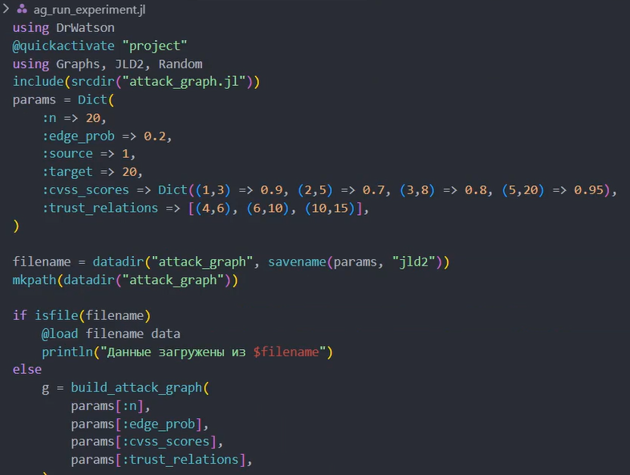

Рисунок 2: Файл ag_run_experiment.jl

## Однократный запуск эксперимента

**Результат:**

В папке data/attack_graph/ создаётся файл. В нём хранятся:

- :graph - объект графа;
- :paths - массив всех путей;
- :metrics - словарь с метриками центральности;
- :weights - веса рёбер;
- :likely_path - массив узлов наиболее вероятного пути;
- :probability - числовая вероятность успеха.

## Однократный запуск эксперимента

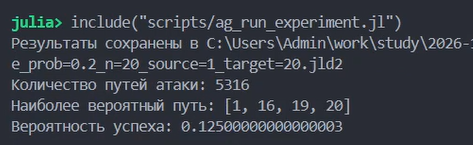

Рисунок 3: Результат выполнения ag_run_experiment.jl в консоли

## Визуализация и анализ графа

Файл scripts/ag_analyze.jl загружает сохранённые данные. Строит наглядное изображение графа (с цветовой индикацией по PageRank). Выводит статистику: количество узлов, рёбер, пути, топ-5 критичных узлов по in-degree и PageRank.

## Визуализация и анализ графа

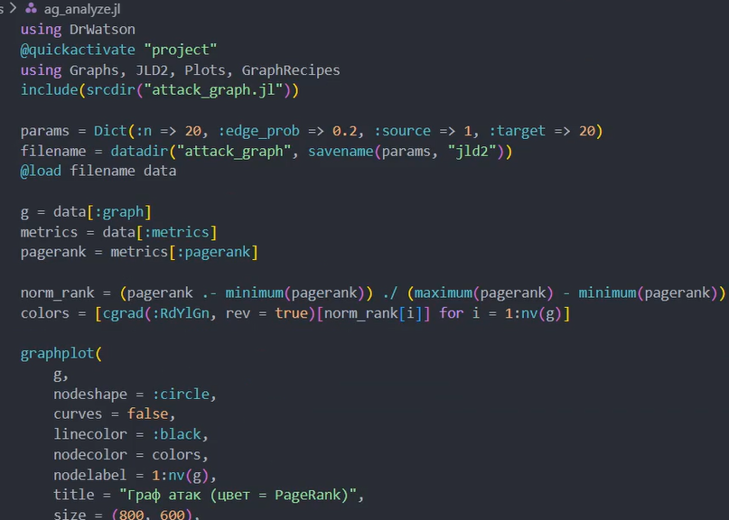

Рисунок 4: Файл ag_analyze.jl

## Визуализация и анализ графа

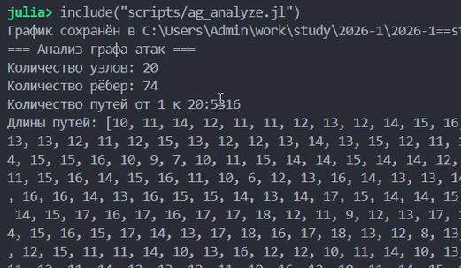

Рисунок 5: Результат выполнения ag_analyze.jl в консоли

## Визуализация и анализ графа

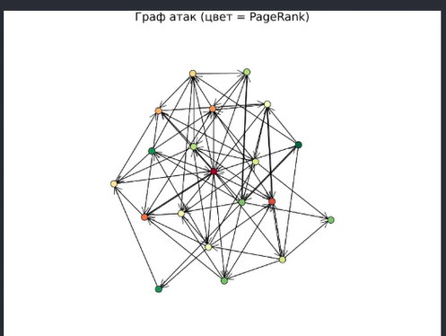

Рисунок 6: Результат выполнения ag_analyze.jl

## Исследование масштабируемости

Файл scripts/ag_convergence.jl исследует, как размер сети (число узлов) влияет на время поиска всех путей и на количество найденных путей. Позволяет оценить вычислительную сложность алгоритма.

## Исследование масштабируемости

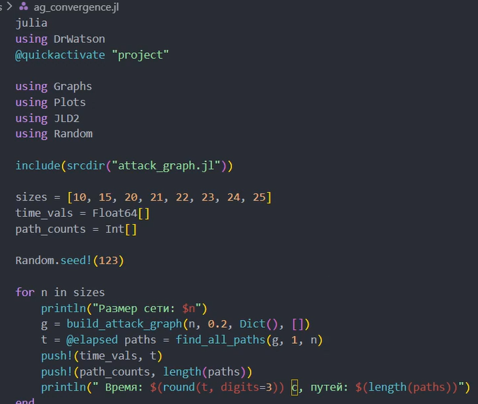

Рисунок 7: Файл ag_convergence.jl

## Исследование масштабируемости

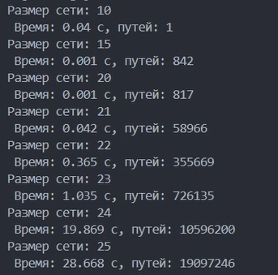

## Исследование масштабируемости

[figure not shown]

Рисунок 9: Сохранённый файл - результат выполнения convergence.jl

## Параметрическое исследование

Файл scripts/parameter_sweep.jl изучает, как изменение плотности рёбер (вероятности случайного ребра) влияет на количество путей атаки, максимальную входящую степень и среднюю длину пути.

## Параметрическое исследование

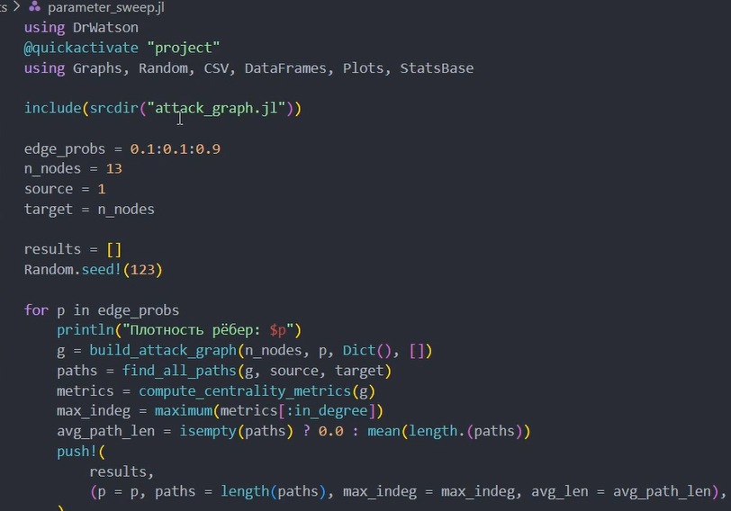

Рисунок 10: Файл parameter_sweep.jl

## Параметрическое исследование

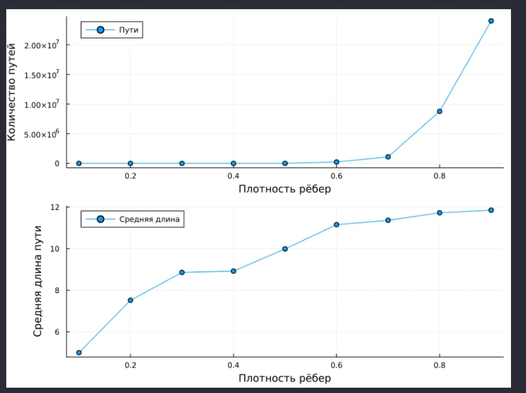

Рисунок 11: Полученный график - результат выполнения parameter_sweep.jl

## Параметрическое исследование

[figure not shown]

Рисунок 12: Сохранённый файл - результат выполнения parameter_sweep.jl

## Преобразование кода в различные форматы

Преобразуем код в литературный стиль.

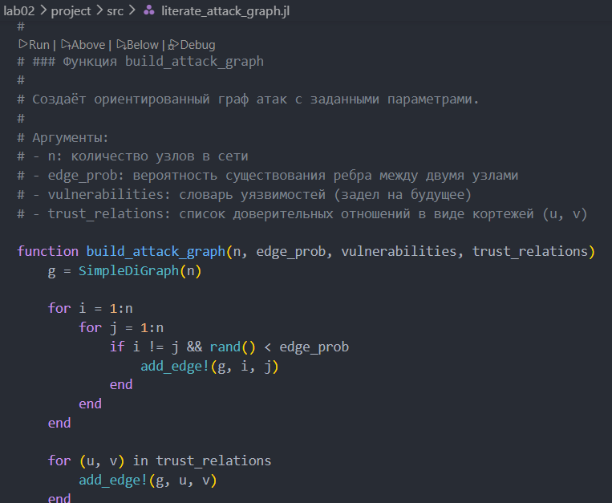

Рисунок 13: Преобразование кода

## Преобразование кода в различные форматы

Сгенерируем из литературного кода чистый код, Jupyter Notebook и документацию в формате Quarto.

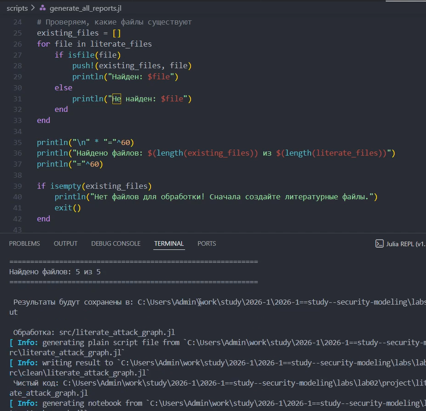

Рисунок 14: Генерация производных форматов

## Преобразование кода в различные форматы

Интегрируем документацию в формате Quarto в отчёт.

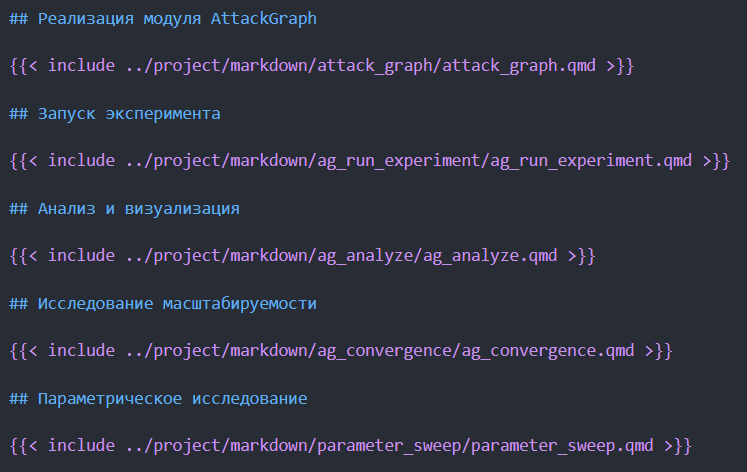

Рисунок 15: Интеграция Quarto

## Выводы

В результате данной лабораторной работы освоены методы построения и анализа графов атак для оценки уязвимостей сетевой инфраструктуры, а также выполнен пример моделирования атак на корпоративную сеть.

## Список литературы

1. JuliaLang [Электронный ресурс]. 2024 JuliaLang.org contributors. URL: https://julialang.org/ (дата обращения: 11.10.2024).
2. Literate.jl Documentation [Электронный ресурс]. Fredrik Ekre. URL: https://fredrikekre.github.io/Literate.jl/v2/ (дата обращения: 11.10.2024).
3. DrWatson.jl Documentation [Электронный ресурс]. JuliaDynamics. URL: https://juliadynamics.github.io/DrWatson.jl/stable/ (дата обращения: 11.10.2024).